# Digit dataset backpropagation

By Gerrit van de Bunt, 1756708, 2020-2021\ In this short notebook we will analyse the digit dataset and, based on this analysis, configure a Neural Network using our own code to train upon and classify the entries in this dataset.

# Step 0

Import the necessary tools.\ **Note: Due to jupyter notebook importing issues, we will be using a couple of cells to define all the code in our notebook, which drastically increases it's size.**

```python
from sklearn.datasets import load_digits
from sklearn.model_selection import train_test_split
from sklearn.metrics import accuracy_score
import matplotlib.pyplot as plt
import numpy as np
import seaborn as sns
import pandas
import random
import time
```

```python
# Activation classes. The idea is as follows;
# The classes should have attributes, but should ultimately be callable to be used in the Perceptrons, in order
# to return an output.

# To this end, make sure that implemented classes have an activate() function that only takes a int or float input
# and outputs a int or float.

from typing import Union
import math

class Step:
    """Step-based activation. If the sum of the input is above the treshold, the output is 1. Otherwise,
    the output is 0."""
    def __init__(self, treshold: Union[int, float] = 0):
        self.treshold = treshold

    def activate(self, input: Union[int, float]):
        if input >= self.treshold:
            return 1
        else:
            return 0

class Sigmoid:
    """Sigmoid-based activation. The output is defined by the sigmoid function."""
    def __init__(self):
        """Creates the object."""

    def activate(self, input: Union[int, float]):
        return 1 / (1 + (math.e ** -input))
```

```python
# Neuron class. Takes a list of inputs, applies a list of weights to them, adds a bias,
# then applies the sum of that to the activation function and returns an output.

from typing import List, Union

class Neuron:
    """Neuron class. To initialise, takes a list of weights, an activation function (normally Sigmoid().activate()), and a bias (optional).
    Once initialised, can be activated by giving a list of inputs (with equal elements to the amount of weights)"""
    def __init__(self, weights: List[Union[int, float]], activation: callable, ID=0, bias: Union[int,float] = 0.0):
        """Initialises the neuron."""
        # FUNCTIONAL VARIABLES (Private)
        self.__weights = weights
        self.__activation = activation
        self.__bias = bias

        self.__newweights = []
        self.__newbias = 0

        # LOGGING VARIABLES (Public)
        self.ID = ID  # Identifier for Perceptron, for debugging.

        self.error = 0  # Error calculated by the error methods.

        self.hasrun = False  # Whether the neuron has been activated or not.
        self.input = []  # Inputs of previous activations
        self.output = []  # Output of previous activations

    def getweights(self) -> List[Union[int, float]]:
        """Returns the current weights."""
        return self.__weights

    def setweights(self,weights: List[Union[int, float]]):
        """Changes the weights on this neuron by using a supplied weightslist.
        For proper use in the PerceptronLayer class, the input has to have the same
        amount of elements as the original weights list."""
        if not len(weights) == len(self.getweights()):
            raise Exception("Amount of supplied weights does not equal the amount of current weights @ Perceptron {}".format(self.ID))
        self.__weights = weights

    def getactivation(self) -> callable:
        """Returns the current activation function."""
        return self.__activation

    def setactivation(self, func: callable):
        """Changes the activation function on this neuron."""
        self.__activation = func

    def getbias(self) -> Union[int, float]:
        """Returns the current bias for this neuron."""
        return self.__bias

    def setbias(self, b: Union[int, float]):
        """Changes the current bias on this neuron."""
        self.__bias = b

    def activate(self,inputs: List[Union[int, float]]) -> Union[int,float]:
        """Activates the Perceptron by supplying inputs."""
        # RESETS
        self.hasrun = False
        # PRECHECKS
        if not len(inputs) == len(self.__weights):
            raise Exception("Amount of inputs is not equal to the amount of weights @ Perceptron {}".format(self.ID))
        # PROCESSING
        weightedlist = []  # List with processed inputs (input*weight)

        for indx in range(len(self.__weights)):
            weightedlist.append(self.__weights[indx] * inputs[indx])

        output = self.__activation(sum(weightedlist) + self.__bias)
        # Consider evaluation succesful past this point; get logging variables.
        self.hasrun = True
        self.input.append(inputs)
        self.output.append(output)

        return output

    def erroroutput(self, target: Union[int,float], learningrate: Union[int,float]):
        """Calculates the error of an output neuron."""
        if not self.hasrun:
            raise Exception("Run the Neuron first! @ Neuron {}".format(self.ID))
        gradients = []
        deltaweights = []
        deltabias = 0
        newweights = []
        newbias = 0
        # Bepaal de error
        output = self.output[-1]
        error = output * (1-output) * -(target-output)
        for inp in self.input[-1]:
            gradients.append(inp * error)  # De output van een voorgaande node is gelijk aan de input op deze node op de relevante index
        for grad in gradients:
            deltaweights.append(learningrate * grad)
        deltabias = learningrate * error

        self.error = error
        self.__newweights = [self.__weights[i] - deltaweights[i] for i in range(len(self.getweights()))]
        self.__newbias = self.getbias() - deltabias

    def errorhidden(self, connections: List[Union[int,float]], errors: List[Union[int,float]], learningrate: Union[int,float]):
        """Calculates the error of a hidden layer neuron"""
        if not self.hasrun:
            raise Exception("Run the Neuron first! @ Neuron {}".format(self.ID))
        if len(connections) != len(errors):
            raise Exception("Amount of connections from this neuron should equal the amount of errors from neurons @ Neuron {}".format(self.ID))
        gradients = []
        deltaweights = []
        deltabias = 0
        newweights = []
        newbias = 0
        csum = 0  # Sum of (Wi,j * Delta(j))
        # Bepaal de error
        output = self.output[-1]
        for i in range(len(connections)):  # Bepaal eerst de som van de vermenigvuldigingen tussen de verbindingen en de errors.
            csum += connections[i] * errors[i]
        error = output * (1-output) * csum  # Bepaal dan uiteindelijk de error.
        for inp in self.input[-1]:
            gradients.append(inp * error)  # De output van een voorgaande node is gelijk aan de input op deze node op de relevante index
        for grad in gradients:
            deltaweights.append(learningrate * grad)
        deltabias = learningrate * error

        self.error = error
        self.__newweights = [self.__weights[i] - deltaweights[i] for i in range(len(self.getweights()))]
        self.__newbias = self.getbias() - deltabias

    def update(self):
        """Updates the weights and bias using stored new weights and bias."""
        self.setbias(self.__newbias)
        self.setweights(self.__newweights)

    def __str__(self) -> str:
        """Returns a string representing the object and it's variables."""
        output = ""
        output += "NEURON ID: {}\n\n".format(self.ID)

        output += "WEIGHTS: {}\n".format(self.getweights())
        output += "ACTIVATION: {}\n".format(self.getactivation().__name__)
        output += "BIAS: {}\n".format(self.getbias())

        if self.hasrun:
            output += "SUCCESFUL ACTIVATION \n\n".format(self.hasrun)
            output += "INPUT: {}\n".format(self.input)
            output += "OUTPUT: {}\n".format(self.output)
        else:
            output += "ACTIVATION PENDING/FAILED\n"

        return output
```

```python
# NeuronLayer defines the layers in the network. This is where the Neuron Class is used.

# By default, all the Layers must be connected, so each neuron in the network must have equally as many
# weights as one another, and the amount of weights on all perceptrons should equal the amount of connections from one layer to the
# other on a per-neuron basis.

from typing import List, Union, Any

class NeuronLayer:
    """Defines a layer in a NeuronNetwork."""
    def __init__(self, neurons: List[Neuron], ID: Any = 0):
        self.neurons = neurons
        self.outputs = []

    def activate(self, inputlist: List[Union[int, float]]):
        """Runs the inputlist through all perceptrons of the network and saves the output."""
        self.outputs = []
        for i in self.neurons:
            i.activate(inputlist)
            self.outputs.append(i.output[-1])
```

```python
# The NeuronLayer houses **all** the layers of the network.

from typing import List, Union, Any  # Onschuldige library die alleen beter laat zien wat voor soorten inputs er verwacht worden.

class NeuronNetwork:
    """Defines the neuron network; wraps all the given layers into this network."""
    def __init__(self, layers: List[NeuronLayer], learningrate: Union[int,float] = 0.3, ID: Any = 0,):
        """Initialises a neuron network. Handles the connections between the layers."""
        self.hiddenlayers = layers
        self.learningrate = learningrate
        self.input = []
        self.output = []

        self.ID = ID
        self.hasrun = False

    def feed_forward(self, inputs: List[Union[int,float]]) -> List[Union[int,float]]:
        """Starts the network, feeds in the inputs, runs it through all the layers and returns the output
        of the final layer."""
        self.hasrun = False
        totalinputs = inputs.copy()  # Keep both lists unlinked; original list will be saved for debugging.
        for layer in self.hiddenlayers:
            layer.activate(totalinputs)
            totalinputs = layer.outputs.copy()  # Same deal here

        self.input = inputs
        self.output = totalinputs
        self.hasrun = True

        return totalinputs

    def backpropagation(self, actualoutput):
        outputlayer = self.hiddenlayers[-1]

        if len(outputlayer.neurons) != len(actualoutput):
            raise Exception("Not enough outputs for each neuron in the output layer @ NeuronNetwork {}".format(self.ID))

        for i in range(len(outputlayer.neurons)):
            outputlayer.neurons[i].erroroutput(actualoutput[i],self.learningrate)
        # Nu komt het lastige gedeelte...
        # Amount of connections is equal to the amount of neurons in the previous layer!!
        # Currentlayer (i) : Target to call .errorhidden() on. Also get index in the neuron list.
        # Nextlayer (i+1) : Target to get weights from. Use index acquired in the previous layer.
        for lindx in range(len(self.hiddenlayers)-2,-1,-1):
            for i in range(len(self.hiddenlayers[lindx].neurons)):
                weights = []
                errors = []
                for neuron in self.hiddenlayers[lindx+1].neurons:
                    weights.append(neuron.getweights()[i])  # Gets the weights that this neuron connects to on neurons in the next layer
                    errors.append(neuron.error)  # Gets the error at the same time.
                self.hiddenlayers[lindx].neurons[i].errorhidden(weights,errors,self.learningrate)

    def update(self):
        """Updates all the weights and biases in the network immediately, given
        that all neurons have had their """
        for layer in self.hiddenlayers:
            for neuron in layer.neurons:
                neuron.update()

    def train(self, inputs: List[List[int]], actualoutputs: List[List[int]], epochs: int = 40, errortreshold: float = 0.1) -> None:
        error = errortreshold+1
        while epochs > 0 and error >= errortreshold:
            for i in range(len(inputs)):
                self.feed_forward(inputs[i])
                self.backpropagation(actualoutputs[i])
                self.update()
            error = self.error(inputs,actualoutputs)  # MSE
            epochs -= 1

    def error(self, inputs: List[List[Union[int,float]]], actualoutputs: List[List[Union[int,float]]]) -> float:
        """Calculates the MSE of this network's output layer over a training set."""
        outputs = []
        sumoutputs = []
        for i in range(len(inputs)):
            self.feed_forward(inputs[i])
            outputs.append(self.output)
            # Verwijder ook hier weer de resulterende inputs en outputs, die willen we niet; error moet gezien
            # worden als een functie zonder side-effects.
            for neuronlayer in self.hiddenlayers:
                for neuron in neuronlayer.neurons:
                    del neuron.output[-1]
                    del neuron.input[-1]

        for i1 in range(len(outputs)):
            for i2 in range(len(outputs[i1])):
                sumoutputs.append((actualoutputs[i1][i2] - outputs[i1][i2])**2)

        return sum(sumoutputs) / len(outputs)

    def __str__(self):
        """Tries to print out the network in a readable manner.
        Additional information is available once the network has been run once."""
        output = ""
        output += "NEURONNETWORK ID: {}\n".format(self.ID)
        if self.hasrun:
            output += "INPUT: {}\nV\n".format(self.input)
        for layer in self.hiddenlayers:
            for i in layer.neurons:
                output += "[{} + {}]\n".format([round(x,4) for x in i.getweights()],round(i.getbias(),4))
            if self.hasrun:
                output += "OUTPUT: {}\n".format(layer.outputs)
            output += "V\n"
        if self.hasrun:
            output += "FINAL OUTPUT: {}\n".format(self.output)
        else:
            output += "ACTIVATION PENDING\n"
        return output
```

# Stap 1 - Data collection

Importeer de dataset en kijk naar de eerste gegevens

```python
data = load_digits(as_frame=True)
frame = data["frame"]
frame
```

|  | pixel_0_0 | pixel_0_1 | pixel_0_2 | pixel_0_3 | pixel_0_4 | pixel_0_5 | pixel_0_6 | pixel_0_7 | pixel_1_0 | pixel_1_1 | ... | pixel_6_7 | pixel_7_0 | pixel_7_1 | pixel_7_2 | pixel_7_3 | pixel_7_4 | pixel_7_5 | pixel_7_6 | pixel_7_7 | target |
| --- | --- | --- | --- | --- | --- | --- | --- | --- | --- | --- | --- | --- | --- | --- | --- | --- | --- | --- | --- | --- | --- |
| 0 | 0.0 | 0.0 | 5.0 | 13.0 | 9.0 | 1.0 | 0.0 | 0.0 | 0.0 | 0.0 | ... | 0.0 | 0.0 | 0.0 | 6.0 | 13.0 | 10.0 | 0.0 | 0.0 | 0.0 | 0 |
| 1 | 0.0 | 0.0 | 0.0 | 12.0 | 13.0 | 5.0 | 0.0 | 0.0 | 0.0 | 0.0 | ... | 0.0 | 0.0 | 0.0 | 0.0 | 11.0 | 16.0 | 10.0 | 0.0 | 0.0 | 1 |
| 2 | 0.0 | 0.0 | 0.0 | 4.0 | 15.0 | 12.0 | 0.0 | 0.0 | 0.0 | 0.0 | ... | 0.0 | 0.0 | 0.0 | 0.0 | 3.0 | 11.0 | 16.0 | 9.0 | 0.0 | 2 |
| 3 | 0.0 | 0.0 | 7.0 | 15.0 | 13.0 | 1.0 | 0.0 | 0.0 | 0.0 | 8.0 | ... | 0.0 | 0.0 | 0.0 | 7.0 | 13.0 | 13.0 | 9.0 | 0.0 | 0.0 | 3 |
| 4 | 0.0 | 0.0 | 0.0 | 1.0 | 11.0 | 0.0 | 0.0 | 0.0 | 0.0 | 0.0 | ... | 0.0 | 0.0 | 0.0 | 0.0 | 2.0 | 16.0 | 4.0 | 0.0 | 0.0 | 4 |
| ... | ... | ... | ... | ... | ... | ... | ... | ... | ... | ... | ... | ... | ... | ... | ... | ... | ... | ... | ... | ... | ... |
| 1792 | 0.0 | 0.0 | 4.0 | 10.0 | 13.0 | 6.0 | 0.0 | 0.0 | 0.0 | 1.0 | ... | 0.0 | 0.0 | 0.0 | 2.0 | 14.0 | 15.0 | 9.0 | 0.0 | 0.0 | 9 |
| 1793 | 0.0 | 0.0 | 6.0 | 16.0 | 13.0 | 11.0 | 1.0 | 0.0 | 0.0 | 0.0 | ... | 0.0 | 0.0 | 0.0 | 6.0 | 16.0 | 14.0 | 6.0 | 0.0 | 0.0 | 0 |
| 1794 | 0.0 | 0.0 | 1.0 | 11.0 | 15.0 | 1.0 | 0.0 | 0.0 | 0.0 | 0.0 | ... | 0.0 | 0.0 | 0.0 | 2.0 | 9.0 | 13.0 | 6.0 | 0.0 | 0.0 | 8 |
| 1795 | 0.0 | 0.0 | 2.0 | 10.0 | 7.0 | 0.0 | 0.0 | 0.0 | 0.0 | 0.0 | ... | 0.0 | 0.0 | 0.0 | 5.0 | 12.0 | 16.0 | 12.0 | 0.0 | 0.0 | 9 |
| 1796 | 0.0 | 0.0 | 10.0 | 14.0 | 8.0 | 1.0 | 0.0 | 0.0 | 0.0 | 2.0 | ... | 0.0 | 0.0 | 1.0 | 8.0 | 12.0 | 14.0 | 12.0 | 1.0 | 0.0 | 8 |

1797 rows × 65 columns

```python
# Normaliseer de pixels!
frame.describe()
```

|  | pixel_0_0 | pixel_0_1 | pixel_0_2 | pixel_0_3 | pixel_0_4 | pixel_0_5 | pixel_0_6 | pixel_0_7 | pixel_1_0 | pixel_1_1 | ... | pixel_6_7 | pixel_7_0 | pixel_7_1 | pixel_7_2 | pixel_7_3 | pixel_7_4 | pixel_7_5 | pixel_7_6 | pixel_7_7 | target |
| --- | --- | --- | --- | --- | --- | --- | --- | --- | --- | --- | --- | --- | --- | --- | --- | --- | --- | --- | --- | --- | --- |
| count | 1797.0 | 1797.000000 | 1797.000000 | 1797.000000 | 1797.000000 | 1797.000000 | 1797.000000 | 1797.000000 | 1797.000000 | 1797.000000 | ... | 1797.000000 | 1797.000000 | 1797.000000 | 1797.000000 | 1797.000000 | 1797.000000 | 1797.000000 | 1797.000000 | 1797.000000 | 1797.000000 |
| mean | 0.0 | 0.303840 | 5.204786 | 11.835838 | 11.848080 | 5.781859 | 1.362270 | 0.129661 | 0.005565 | 1.993879 | ... | 0.206455 | 0.000556 | 0.279354 | 5.557596 | 12.089037 | 11.809126 | 6.764051 | 2.067891 | 0.364496 | 4.490818 |
| std | 0.0 | 0.907192 | 4.754826 | 4.248842 | 4.287388 | 5.666418 | 3.325775 | 1.037383 | 0.094222 | 3.196160 | ... | 0.984401 | 0.023590 | 0.934302 | 5.103019 | 4.374694 | 4.933947 | 5.900623 | 4.090548 | 1.860122 | 2.865304 |
| min | 0.0 | 0.000000 | 0.000000 | 0.000000 | 0.000000 | 0.000000 | 0.000000 | 0.000000 | 0.000000 | 0.000000 | ... | 0.000000 | 0.000000 | 0.000000 | 0.000000 | 0.000000 | 0.000000 | 0.000000 | 0.000000 | 0.000000 | 0.000000 |
| 25% | 0.0 | 0.000000 | 1.000000 | 10.000000 | 10.000000 | 0.000000 | 0.000000 | 0.000000 | 0.000000 | 0.000000 | ... | 0.000000 | 0.000000 | 0.000000 | 1.000000 | 11.000000 | 10.000000 | 0.000000 | 0.000000 | 0.000000 | 2.000000 |
| 50% | 0.0 | 0.000000 | 4.000000 | 13.000000 | 13.000000 | 4.000000 | 0.000000 | 0.000000 | 0.000000 | 0.000000 | ... | 0.000000 | 0.000000 | 0.000000 | 4.000000 | 13.000000 | 14.000000 | 6.000000 | 0.000000 | 0.000000 | 4.000000 |
| 75% | 0.0 | 0.000000 | 9.000000 | 15.000000 | 15.000000 | 11.000000 | 0.000000 | 0.000000 | 0.000000 | 3.000000 | ... | 0.000000 | 0.000000 | 0.000000 | 10.000000 | 16.000000 | 16.000000 | 12.000000 | 2.000000 | 0.000000 | 7.000000 |
| max | 0.0 | 8.000000 | 16.000000 | 16.000000 | 16.000000 | 16.000000 | 16.000000 | 15.000000 | 2.000000 | 16.000000 | ... | 13.000000 | 1.000000 | 9.000000 | 16.000000 | 16.000000 | 16.000000 | 16.000000 | 16.000000 | 16.000000 | 9.000000 |

8 rows × 65 columns

```python
sample = frame.sample(10)
sample
```

|  | pixel_0_0 | pixel_0_1 | pixel_0_2 | pixel_0_3 | pixel_0_4 | pixel_0_5 | pixel_0_6 | pixel_0_7 | pixel_1_0 | pixel_1_1 | ... | pixel_6_7 | pixel_7_0 | pixel_7_1 | pixel_7_2 | pixel_7_3 | pixel_7_4 | pixel_7_5 | pixel_7_6 | pixel_7_7 | target |
| --- | --- | --- | --- | --- | --- | --- | --- | --- | --- | --- | --- | --- | --- | --- | --- | --- | --- | --- | --- | --- | --- |
| 369 | 0.0 | 0.0 | 7.0 | 12.0 | 12.0 | 2.0 | 0.0 | 0.0 | 0.0 | 5.0 | ... | 0.0 | 0.0 | 0.0 | 11.0 | 12.0 | 13.0 | 14.0 | 11.0 | 0.0 | 2 |
| 988 | 0.0 | 0.0 | 0.0 | 4.0 | 15.0 | 2.0 | 0.0 | 0.0 | 0.0 | 0.0 | ... | 0.0 | 0.0 | 0.0 | 0.0 | 7.0 | 16.0 | 6.0 | 0.0 | 0.0 | 4 |
| 791 | 0.0 | 1.0 | 8.0 | 16.0 | 16.0 | 16.0 | 10.0 | 0.0 | 0.0 | 8.0 | ... | 0.0 | 0.0 | 1.0 | 13.0 | 12.0 | 0.0 | 0.0 | 0.0 | 0.0 | 5 |
| 437 | 0.0 | 0.0 | 12.0 | 15.0 | 3.0 | 0.0 | 0.0 | 0.0 | 0.0 | 6.0 | ... | 0.0 | 0.0 | 0.0 | 9.0 | 8.0 | 13.0 | 15.0 | 7.0 | 0.0 | 2 |
| 994 | 0.0 | 0.0 | 2.0 | 13.0 | 1.0 | 0.0 | 0.0 | 0.0 | 0.0 | 0.0 | ... | 2.0 | 0.0 | 0.0 | 2.0 | 12.0 | 12.0 | 12.0 | 13.0 | 8.0 | 1 |
| 380 | 0.0 | 0.0 | 0.0 | 6.0 | 16.0 | 2.0 | 0.0 | 0.0 | 0.0 | 0.0 | ... | 0.0 | 0.0 | 0.0 | 0.0 | 10.0 | 15.0 | 0.0 | 0.0 | 0.0 | 4 |
| 736 | 0.0 | 1.0 | 11.0 | 16.0 | 15.0 | 12.0 | 3.0 | 0.0 | 0.0 | 1.0 | ... | 0.0 | 0.0 | 0.0 | 8.0 | 16.0 | 12.0 | 0.0 | 0.0 | 0.0 | 1 |
| 1778 | 0.0 | 0.0 | 0.0 | 1.0 | 13.0 | 8.0 | 0.0 | 0.0 | 0.0 | 0.0 | ... | 0.0 | 0.0 | 0.0 | 0.0 | 0.0 | 15.0 | 7.0 | 0.0 | 0.0 | 4 |
| 141 | 0.0 | 0.0 | 0.0 | 0.0 | 7.0 | 13.0 | 5.0 | 0.0 | 0.0 | 0.0 | ... | 0.0 | 0.0 | 0.0 | 0.0 | 0.0 | 8.0 | 12.0 | 0.0 | 0.0 | 1 |
| 1522 | 0.0 | 0.0 | 0.0 | 1.0 | 10.0 | 16.0 | 8.0 | 0.0 | 0.0 | 1.0 | ... | 0.0 | 0.0 | 0.0 | 0.0 | 0.0 | 10.0 | 16.0 | 7.0 | 0.0 | 1 |

10 rows × 65 columns

# Stap 2 - Data analyse

Aangezien we hier te maken hebben met de pixel intensiteiten op een 8x8 ruimte, zijn we vooral geinteresseerd in hoe een paar voorbeelden eruit zien.

De data gaat hier over de intensiteit van een kleur van een pixel (8x8: 0 tot 7 voor rijen en kolommen)

```python
pixelsample = sample.drop('target',axis=1)
pixelsample
```

|  | pixel_0_0 | pixel_0_1 | pixel_0_2 | pixel_0_3 | pixel_0_4 | pixel_0_5 | pixel_0_6 | pixel_0_7 | pixel_1_0 | pixel_1_1 | ... | pixel_6_6 | pixel_6_7 | pixel_7_0 | pixel_7_1 | pixel_7_2 | pixel_7_3 | pixel_7_4 | pixel_7_5 | pixel_7_6 | pixel_7_7 |
| --- | --- | --- | --- | --- | --- | --- | --- | --- | --- | --- | --- | --- | --- | --- | --- | --- | --- | --- | --- | --- | --- |
| 369 | 0.0 | 0.0 | 7.0 | 12.0 | 12.0 | 2.0 | 0.0 | 0.0 | 0.0 | 5.0 | ... | 2.0 | 0.0 | 0.0 | 0.0 | 11.0 | 12.0 | 13.0 | 14.0 | 11.0 | 0.0 |
| 988 | 0.0 | 0.0 | 0.0 | 4.0 | 15.0 | 2.0 | 0.0 | 0.0 | 0.0 | 0.0 | ... | 0.0 | 0.0 | 0.0 | 0.0 | 0.0 | 7.0 | 16.0 | 6.0 | 0.0 | 0.0 |
| 791 | 0.0 | 1.0 | 8.0 | 16.0 | 16.0 | 16.0 | 10.0 | 0.0 | 0.0 | 8.0 | ... | 0.0 | 0.0 | 0.0 | 1.0 | 13.0 | 12.0 | 0.0 | 0.0 | 0.0 | 0.0 |
| 437 | 0.0 | 0.0 | 12.0 | 15.0 | 3.0 | 0.0 | 0.0 | 0.0 | 0.0 | 6.0 | ... | 5.0 | 0.0 | 0.0 | 0.0 | 9.0 | 8.0 | 13.0 | 15.0 | 7.0 | 0.0 |
| 994 | 0.0 | 0.0 | 2.0 | 13.0 | 1.0 | 0.0 | 0.0 | 0.0 | 0.0 | 0.0 | ... | 9.0 | 2.0 | 0.0 | 0.0 | 2.0 | 12.0 | 12.0 | 12.0 | 13.0 | 8.0 |
| 380 | 0.0 | 0.0 | 0.0 | 6.0 | 16.0 | 2.0 | 0.0 | 0.0 | 0.0 | 0.0 | ... | 0.0 | 0.0 | 0.0 | 0.0 | 0.0 | 10.0 | 15.0 | 0.0 | 0.0 | 0.0 |
| 736 | 0.0 | 1.0 | 11.0 | 16.0 | 15.0 | 12.0 | 3.0 | 0.0 | 0.0 | 1.0 | ... | 0.0 | 0.0 | 0.0 | 0.0 | 8.0 | 16.0 | 12.0 | 0.0 | 0.0 | 0.0 |
| 1778 | 0.0 | 0.0 | 0.0 | 1.0 | 13.0 | 8.0 | 0.0 | 0.0 | 0.0 | 0.0 | ... | 0.0 | 0.0 | 0.0 | 0.0 | 0.0 | 0.0 | 15.0 | 7.0 | 0.0 | 0.0 |
| 141 | 0.0 | 0.0 | 0.0 | 0.0 | 7.0 | 13.0 | 5.0 | 0.0 | 0.0 | 0.0 | ... | 0.0 | 0.0 | 0.0 | 0.0 | 0.0 | 0.0 | 8.0 | 12.0 | 0.0 | 0.0 |
| 1522 | 0.0 | 0.0 | 0.0 | 1.0 | 10.0 | 16.0 | 8.0 | 0.0 | 0.0 | 1.0 | ... | 3.0 | 0.0 | 0.0 | 0.0 | 0.0 | 0.0 | 10.0 | 16.0 | 7.0 | 0.0 |

10 rows × 64 columns

```python
def generatepixelarray(data: pandas.Series, dataindex: int, xbound: int, ybound: int):
    """Turns a given list into a pixel array."""
    test = data.iloc[dataindex].tolist()
    new = []
    x = 0
    for y in range(ybound):
        new.append([])
        for i in range(xbound):
            new[y].append(test[x])
            x += 1
    return np.array(new)
```

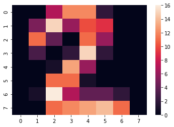

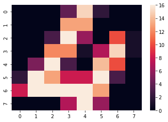

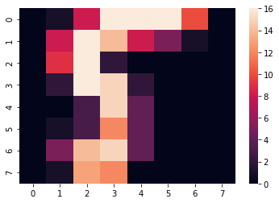

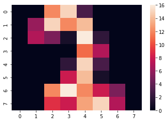

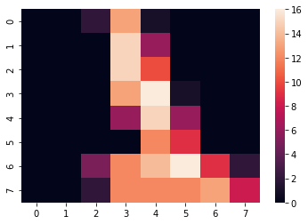

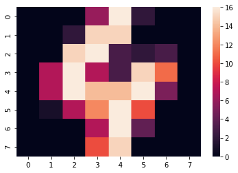

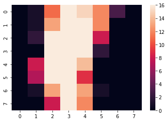

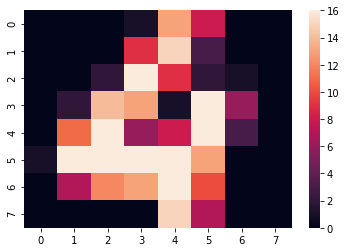

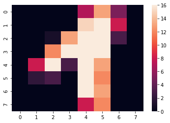

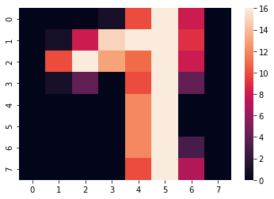

```python
for i in range(0,10):
    plt.show(sns.heatmap(generatepixelarray(pixelsample,i,8,8)))
```

**Notitie: Deze dataset is al helemaal 'clean'; Data cleanup en Data preparation is hier niet nodig, deze stappen slaan we dus over. We zullen wel tijdens het organiseren van de testdata de data overzetten naar een list; kennelijk ontstaan er makkelijk errors als we direct een pandas dataframe gebruiken. Verder maken we ook dummies van y, zodat deze in ons netwerk passen.**

# Stap 3 - Model trainen

We gaan het bovengenoemde model in de realiteit brengen. Hiervoor hoeven we alleen nog onze features/targets organiseren en de train/test data.

```python
frame
```

|  | pixel_0_0 | pixel_0_1 | pixel_0_2 | pixel_0_3 | pixel_0_4 | pixel_0_5 | pixel_0_6 | pixel_0_7 | pixel_1_0 | pixel_1_1 | ... | pixel_6_7 | pixel_7_0 | pixel_7_1 | pixel_7_2 | pixel_7_3 | pixel_7_4 | pixel_7_5 | pixel_7_6 | pixel_7_7 | target |
| --- | --- | --- | --- | --- | --- | --- | --- | --- | --- | --- | --- | --- | --- | --- | --- | --- | --- | --- | --- | --- | --- |
| 0 | 0.0 | 0.0 | 5.0 | 13.0 | 9.0 | 1.0 | 0.0 | 0.0 | 0.0 | 0.0 | ... | 0.0 | 0.0 | 0.0 | 6.0 | 13.0 | 10.0 | 0.0 | 0.0 | 0.0 | 0 |
| 1 | 0.0 | 0.0 | 0.0 | 12.0 | 13.0 | 5.0 | 0.0 | 0.0 | 0.0 | 0.0 | ... | 0.0 | 0.0 | 0.0 | 0.0 | 11.0 | 16.0 | 10.0 | 0.0 | 0.0 | 1 |
| 2 | 0.0 | 0.0 | 0.0 | 4.0 | 15.0 | 12.0 | 0.0 | 0.0 | 0.0 | 0.0 | ... | 0.0 | 0.0 | 0.0 | 0.0 | 3.0 | 11.0 | 16.0 | 9.0 | 0.0 | 2 |
| 3 | 0.0 | 0.0 | 7.0 | 15.0 | 13.0 | 1.0 | 0.0 | 0.0 | 0.0 | 8.0 | ... | 0.0 | 0.0 | 0.0 | 7.0 | 13.0 | 13.0 | 9.0 | 0.0 | 0.0 | 3 |
| 4 | 0.0 | 0.0 | 0.0 | 1.0 | 11.0 | 0.0 | 0.0 | 0.0 | 0.0 | 0.0 | ... | 0.0 | 0.0 | 0.0 | 0.0 | 2.0 | 16.0 | 4.0 | 0.0 | 0.0 | 4 |
| ... | ... | ... | ... | ... | ... | ... | ... | ... | ... | ... | ... | ... | ... | ... | ... | ... | ... | ... | ... | ... | ... |
| 1792 | 0.0 | 0.0 | 4.0 | 10.0 | 13.0 | 6.0 | 0.0 | 0.0 | 0.0 | 1.0 | ... | 0.0 | 0.0 | 0.0 | 2.0 | 14.0 | 15.0 | 9.0 | 0.0 | 0.0 | 9 |
| 1793 | 0.0 | 0.0 | 6.0 | 16.0 | 13.0 | 11.0 | 1.0 | 0.0 | 0.0 | 0.0 | ... | 0.0 | 0.0 | 0.0 | 6.0 | 16.0 | 14.0 | 6.0 | 0.0 | 0.0 | 0 |
| 1794 | 0.0 | 0.0 | 1.0 | 11.0 | 15.0 | 1.0 | 0.0 | 0.0 | 0.0 | 0.0 | ... | 0.0 | 0.0 | 0.0 | 2.0 | 9.0 | 13.0 | 6.0 | 0.0 | 0.0 | 8 |
| 1795 | 0.0 | 0.0 | 2.0 | 10.0 | 7.0 | 0.0 | 0.0 | 0.0 | 0.0 | 0.0 | ... | 0.0 | 0.0 | 0.0 | 5.0 | 12.0 | 16.0 | 12.0 | 0.0 | 0.0 | 9 |
| 1796 | 0.0 | 0.0 | 10.0 | 14.0 | 8.0 | 1.0 | 0.0 | 0.0 | 0.0 | 2.0 | ... | 0.0 | 0.0 | 1.0 | 8.0 | 12.0 | 14.0 | 12.0 | 1.0 | 0.0 | 8 |

1797 rows × 65 columns

```python
xframe = frame.drop("target",axis=1)
xframe
```

|  | pixel_0_0 | pixel_0_1 | pixel_0_2 | pixel_0_3 | pixel_0_4 | pixel_0_5 | pixel_0_6 | pixel_0_7 | pixel_1_0 | pixel_1_1 | ... | pixel_6_6 | pixel_6_7 | pixel_7_0 | pixel_7_1 | pixel_7_2 | pixel_7_3 | pixel_7_4 | pixel_7_5 | pixel_7_6 | pixel_7_7 |
| --- | --- | --- | --- | --- | --- | --- | --- | --- | --- | --- | --- | --- | --- | --- | --- | --- | --- | --- | --- | --- | --- |
| 0 | 0.0 | 0.0 | 5.0 | 13.0 | 9.0 | 1.0 | 0.0 | 0.0 | 0.0 | 0.0 | ... | 0.0 | 0.0 | 0.0 | 0.0 | 6.0 | 13.0 | 10.0 | 0.0 | 0.0 | 0.0 |
| 1 | 0.0 | 0.0 | 0.0 | 12.0 | 13.0 | 5.0 | 0.0 | 0.0 | 0.0 | 0.0 | ... | 0.0 | 0.0 | 0.0 | 0.0 | 0.0 | 11.0 | 16.0 | 10.0 | 0.0 | 0.0 |
| 2 | 0.0 | 0.0 | 0.0 | 4.0 | 15.0 | 12.0 | 0.0 | 0.0 | 0.0 | 0.0 | ... | 5.0 | 0.0 | 0.0 | 0.0 | 0.0 | 3.0 | 11.0 | 16.0 | 9.0 | 0.0 |
| 3 | 0.0 | 0.0 | 7.0 | 15.0 | 13.0 | 1.0 | 0.0 | 0.0 | 0.0 | 8.0 | ... | 9.0 | 0.0 | 0.0 | 0.0 | 7.0 | 13.0 | 13.0 | 9.0 | 0.0 | 0.0 |
| 4 | 0.0 | 0.0 | 0.0 | 1.0 | 11.0 | 0.0 | 0.0 | 0.0 | 0.0 | 0.0 | ... | 0.0 | 0.0 | 0.0 | 0.0 | 0.0 | 2.0 | 16.0 | 4.0 | 0.0 | 0.0 |
| ... | ... | ... | ... | ... | ... | ... | ... | ... | ... | ... | ... | ... | ... | ... | ... | ... | ... | ... | ... | ... | ... |
| 1792 | 0.0 | 0.0 | 4.0 | 10.0 | 13.0 | 6.0 | 0.0 | 0.0 | 0.0 | 1.0 | ... | 4.0 | 0.0 | 0.0 | 0.0 | 2.0 | 14.0 | 15.0 | 9.0 | 0.0 | 0.0 |
| 1793 | 0.0 | 0.0 | 6.0 | 16.0 | 13.0 | 11.0 | 1.0 | 0.0 | 0.0 | 0.0 | ... | 1.0 | 0.0 | 0.0 | 0.0 | 6.0 | 16.0 | 14.0 | 6.0 | 0.0 | 0.0 |
| 1794 | 0.0 | 0.0 | 1.0 | 11.0 | 15.0 | 1.0 | 0.0 | 0.0 | 0.0 | 0.0 | ... | 0.0 | 0.0 | 0.0 | 0.0 | 2.0 | 9.0 | 13.0 | 6.0 | 0.0 | 0.0 |
| 1795 | 0.0 | 0.0 | 2.0 | 10.0 | 7.0 | 0.0 | 0.0 | 0.0 | 0.0 | 0.0 | ... | 2.0 | 0.0 | 0.0 | 0.0 | 5.0 | 12.0 | 16.0 | 12.0 | 0.0 | 0.0 |
| 1796 | 0.0 | 0.0 | 10.0 | 14.0 | 8.0 | 1.0 | 0.0 | 0.0 | 0.0 | 2.0 | ... | 8.0 | 0.0 | 0.0 | 1.0 | 8.0 | 12.0 | 14.0 | 12.0 | 1.0 | 0.0 |

1797 rows × 64 columns

```python
processingx = xframe.values.tolist()
processingx
```

[output not shown]

[output cut: 63946 more lines]

[output not shown]

```python
def normalize(test:list):
    """Normalizes a given list."""
    minbound = min(test)
    maxbound = max(test)
    for i in range(len(test)):
        test[i] = (test[i] - minbound)/(maxbound - minbound)
    return test
x = [normalize(x) for x in processingx]
x
```

[output not shown]

[output cut: 63946 more lines]

[output not shown]

```python
yframe = frame["target"]
yframe
```

```
0       0
1       1
2       2
3       3
4       4
       ..
1792    9
1793    0
1794    8
1795    9
1796    8
Name: target, Length: 1797, dtype: int32
```

```python
y = pandas.get_dummies(yframe).values.tolist()
y
```

[output not shown]

[output cut: 986 more lines]

De dataset bevat 1797 plaatjes. Dit is teveel voor ons model om binnen een reeële tijd door heen te gaan (zelfs bij een epoch van 1 zit ik hier nog na 10 minuten te wachten...!). We kiezen er dus voor om de dataset in te perken.

```python
minbound = 0
maxbound = 1347
x, y = x[minbound:maxbound], y[minbound:maxbound]
```

```python
x_train,x_test,y_train,y_test = train_test_split(x,y,random_state=42)
```

```python
# print(len(yframe.unique()))
```

```python
# Definitions
inputs = len(xframe.columns)  # Aantal features
outputs = len(yframe.unique())  # Aantal outputs
neurons = 32  # Aantal neurons in de eerste layer.
eta = 0.4 # Learning rate
epochs = 40  # Aantal keer dat het netwerk door de **hele** trainset heen loopt
errortolerance = 0.01  # Als de MSE onder deze grens ligt, dan houdt het netwerk op met trainen
random.seed(1756708)
# End of definitions
start = time.time()
l1 = NeuronLayer([])
l2 = NeuronLayer([])

for i in range(neurons):  # Tweede layer
    n = Neuron([random.random() for i in range(inputs)],Sigmoid().activate)
    l1.neurons.append(n)

for j in range(outputs):  # Output layer
    n = Neuron([random.random() for i in range(neurons)],Sigmoid().activate)
    l2.neurons.append(n)

ntwrk = NeuronNetwork([l1,l2],learningrate=eta)
ntwrk.train(x_train,y_train,epochs=epochs,errortreshold=errortolerance)
end = time.time()
print("Training network took {} seconds.".format((end-start)))
```

```
Training network took 126.3191339969635 seconds.
```

```python
y_pred = [ntwrk.feed_forward(x) for x in x_test]
indexes_y_pred = [y_pred[i].index(max(y_pred[i])) for i in range(len(y_pred))]
indexes_y_true = [y_test[i].index(max(y_test[i])) for i in range(len(y_test))]
print("Accuracy network:")
print(accuracy_score(indexes_y_pred,indexes_y_true))
print("Error network (RMSE) (trainset):")
print(np.sqrt(ntwrk.error(list(x_train),list(y_train))))
print("Error network (RMSE) (testset):")
print(np.sqrt(ntwrk.error(list(x_test),list(y_test))))
```

```
Accuracy network:
0.12166172106824925
Error network (RMSE) (trainset):
2.9999996129086828
Error network (RMSE) (testset):
2.9999996115189
```

```python
randomindex = random.randrange(len(x))
test = x[randomindex]
awns = y[randomindex]
```

```python
test
```

[output not shown]

[output cut: 9 more lines]

[output not shown]

```python
def generatepixelarray(data: list, dataindex: int, xbound: int, ybound: int):
    """Turns a given list into a pixel array."""
    new = []
    x = 0
    for y in range(ybound):
        new.append([])
        for i in range(xbound):
            new[y].append(test[x])
            x += 1
    return np.array(new)
```

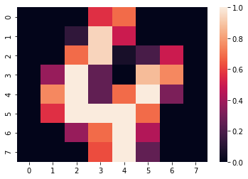

```
4
```

```python
plt.show(sns.heatmap(generatepixelarray(x,randomindex,8,8)))
print(yframe[randomindex])
```

```python
test = x[randomindex]
test
ntwrk.feed_forward(test)
```

```
[0.9999999228259593,
 0.9999999908424079,
 0.9999997732538061,
 0.9999999565677872,
 0.9999997539844491,
 0.9999999729845451,
 0.9999999530229751,
 0.999999652555107,
 0.9999999802397224,
 0.9999997548502467]
```

```python
print(ntwrk.__str__())
```

[output not shown]

[output cut: 36 more lines]

```python
for neuron in ntwrk.hiddenlayers[-1].neurons:
    print(neuron.__str__())
```

[output not shown]